# Soccer DataBase

- Introduction
- Data Wrangling
- Exploratory Data Analysis
- Conclusions

## Introduction: Data Description

> The ultimate Soccer database for data analysis and machine learning What you get:</a>

> +25,000 matches  
> +10,000 players  
> 11 European Countries with their lead championship  
> Seasons 2008 to 2016  
> Players and Teams' attributes sourced from EA Sports' FIFA video game series, including the weekly updates  
> Team line up with squad formation (X, Y coordinates)  
> Betting odds from up to 10 providers  
> Detailed match events (goal types, possession, corner, cross, fouls, cards etc...) for +10,000 matches  
> 16th Oct 2016: New table containing teams' attributes from FIFA !

**Referance: https://www.kaggle.com/hugomathien/soccer**

```python
#Import Packages
import pandas as pd
import numpy as np
import matplotlib.pyplot as plt
import seaborn as sns
from sqlalchemy import create_engine
import re
from sklearn.impute import KNNImputer

import warnings
warnings.filterwarnings("ignore")
plt.style.use('ggplot')

%matplotlib inline
```

## Data Wrangling

> 1. In this section I will use SQL Syntax `(Using sqlalchemy package)` to retrieve all tables from the SQL DataBase file then concatenate the tables using pandas, since pandas provide more fine grain options in merging tables.
> 2. Choose Columns for analysis and inspect missing values.
> 3. Create `target` column for the match outcome to state weather the home-team win, away-team win or draw.
> 4. Impute missing values for the player dataframe using `KNNImputer` provided by scikit-learn package for advanced imputation techniques.

### Retrieve, Join & Choose Columns from Tables

```python
#Use sqlalchemy to read data from SQL database file
database_link = 'database.sqlite'
database = create_engine('sqlite:///' + database_link)
#Print Table names
print(database.table_names())
```

```
['Country', 'League', 'Match', 'Player', 'Player_Attributes', 'Team', 'Team_Attributes', 'sqlite_sequence']
```

```python
#Retrieve tables into Pandas dataframe using the function pd.read_sql_query provided by pandas
country = pd.read_sql_query('SELECT * FROM Country', database)
league = pd.read_sql_query('SELECT * FROM League', database)
match = pd.read_sql_query('SELECT * FROM Match', database)
player = pd.read_sql_query('SELECT * FROM Player', database)
player_attributes = pd.read_sql_query('SELECT * FROM Player_Attributes', database)
team = pd.read_sql_query('SELECT * FROM Team', database)
team_attributes = pd.read_sql_query('SELECT * FROM Team_Attributes', database)
```

```python
#Concatenate tables for analysis
country_league = country.merge(league, left_on='id', right_on='country_id', suffixes=('_country', '_league')).drop('id_country', axis=1)
country_league_match = country_league.merge(match, on='country_id', suffixes=('', '_match')).drop('league_id', axis=1)
country_league_match_team = country_league_match.merge(team, left_on='home_team_api_id', right_on='team_api_id', suffixes=('', '_team'))
df_all = country_league_match_team.merge(team_attributes, on='team_api_id', suffixes=('', '_team_attributes'))
df_player_all = player.merge(player_attributes, on='player_api_id', suffixes=('', '_player_attributes'))
```

```python
#Choose columns for analysis
df_matches = df_all[['name_country', 'name_league', 'season', 'home_team_goal', 'away_team_goal', 'team_long_name']]
df_player = df_player_all[['height', 'weight', 'overall_rating', 'potential']]
```

### Detect then Impute Missing Values using KNN-Imputer & Create a Target Column.

```python
#Calculate the percentage of missing values for each column of df_matches
round(df_matches.isnull().sum()*100 / len(df_matches),2)
```

```
name_country      0.0
name_league       0.0
season            0.0
home_team_goal    0.0
away_team_goal    0.0
team_long_name    0.0
dtype: float64
```

```python
#Creating a target Column

#Create a mask for the winning stats
home_win = df_matches['home_team_goal'] > df_matches['away_team_goal']
away_win = df_matches['home_team_goal'] < df_matches['away_team_goal']
draw = df_matches['home_team_goal'] == df_matches['away_team_goal']

#Create a list of conditions for the winning team along with the mapping values
conditons_target = [home_win, away_win, draw]
choice_target = ['home_win', 'away_win', 'draw']

#Create a target column specifiying the winning stats( home_win , away_win, draw)
df_matches['target'] = np.select(conditons_target, choice_target, default=np.nan)
df_matches.drop(['home_team_goal', 'away_team_goal'], axis=1,inplace=True)
df_matches.columns = ['country', 'league', 'season', 'team', 'target']
```

```python
#Convert Season to an Ordered Categorical Column
seasonal_cat = pd.api.types.CategoricalDtype(categories=['2008/2009', '2009/2010', '2010/2011', '2011/2012', '2012/2013','2013/2014', '2014/2015', '2015/2016'], ordered=True)
df_matches.season = df_matches.season.astype(seasonal_cat)
```

```python
#Inspect Missing Values for the player dataframe
round(df_player.isnull().sum()*100 / len(df_player),2)
```

```
height            0.00
weight            0.00
overall_rating    0.45
potential         0.45
dtype: float64
```

### Impute Missing Values Using KNN-Imputer for the player DataFrame

```python
#Take 1672 samples from complete df_player data (same number of missing values*2)
not_null_sample = df_player.loc[~df_player.potential.isnull()].iloc[:836*2]
is_null = df_player.loc[df_player.potential.isnull()]

#Concatenate the data the contains null values and the does not contain null values vertically
#We don't impute missing values on the complete data
#Imputation algorithm is computationally intensive compared to filling missing values with mean or median
data_to_impute = is_null.append(not_null_sample)
data_to_impute_index = pd.DataFrame(data_to_impute.index.to_list(), columns=['index'])
```

```python
#Instantiate KNNImpute from sklearn library
imputer = KNNImputer()

#fit and transform the imputer on the data
df_player_imputed = imputer.fit_transform(data_to_impute)
df_player_imputed = pd.DataFrame(df_player_imputed, columns=df_player.columns)
df_player_imputed = pd.concat([df_player_imputed, data_to_impute_index], axis=1).set_index('index')

#Update the original data with the imputed values
df_player.update(df_player_imputed)
```

## Exploratory Data Analysis

### Question 1: Does Country, League , or Team have a high association with the match outcome ?

```python
#Describe the matches dataframe and Transpose the results for better readability & analyze the target column
print(df_matches.describe().T)
print('-------------------------------------------------------')
print(round(df_matches.target.value_counts(normalize=True)*100,2))
```

```
          count unique                     top   freq
country  142093     11                 England  18240
league   142093     11  England Premier League  18240
season   142093      8               2012/2013  18279
team     142093    285               Getafe CF    912
target   142093      3                home_win  66949
-------------------------------------------------------
home_win    47.12
away_win    27.65
draw        25.23
Name: target, dtype: float64
```

> **We can see that home-team wins 47.12% of the time, while away-team wins 27.65% of the time.**

### Plot Country, League vs Match Outcome

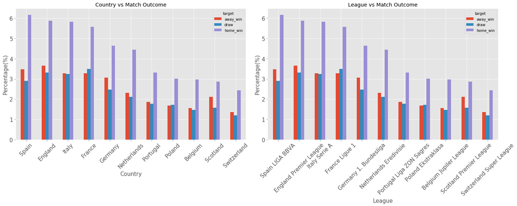

```python
#Make a bar plot for the Country & League vs Match-outcome(target)
#Country vs Match Outcome
ax1 = plt.subplot(1,2,1)
cross_tab_country = pd.crosstab(df_matches['country'], df_matches['target'], normalize=True)*100
cross_tab_country = round(cross_tab_country.sort_values(by='home_win',ascending=False),2)
cross_tab_country.plot(kind = 'bar', figsize=(20,8), title='Country vs Match Outcome', fontsize=15, rot=45, ax=ax1)
plt.xlabel('Country', fontsize=15)
plt.ylabel('Percentage(%)', fontsize=15);

#League vs Match Outcome
ax2 = plt.subplot(1,2,2)
cross_tab_league = pd.crosstab(df_matches['league'], df_matches['target'], normalize=True)*100
cross_tab_league = round(cross_tab_league.sort_values(by='home_win',ascending=False),2)
cross_tab_league.plot(kind = 'bar', figsize=(20,8), title='League vs Match Outcome', fontsize=15, rot=45, ax=ax2)
plt.xlabel('League', fontsize=15)
plt.ylabel('Percentage(%)', fontsize=15)
plt.tight_layout();
```

> **We can see that all of the time home-team wins whether if its grouped by country or by league.**

### Plot Match Outcome by Team

```python
#Create a Cross-tab for teams vs Match-Outcome(target column)
cross_tab_team = pd.crosstab(df_matches['team'], df_matches['target'], normalize=True)*100
cross_tab_team = round(cross_tab_team.sort_values(by='home_win',ascending=False),2)

#Create a away_win_team column where away wins is more than home wins
cross_tab_team['away_win_team'] = cross_tab_team['away_win'] > cross_tab_team['home_win']
away_win_team = round(cross_tab_team.away_win_team.value_counts()*100/len(cross_tab_team),2)
```

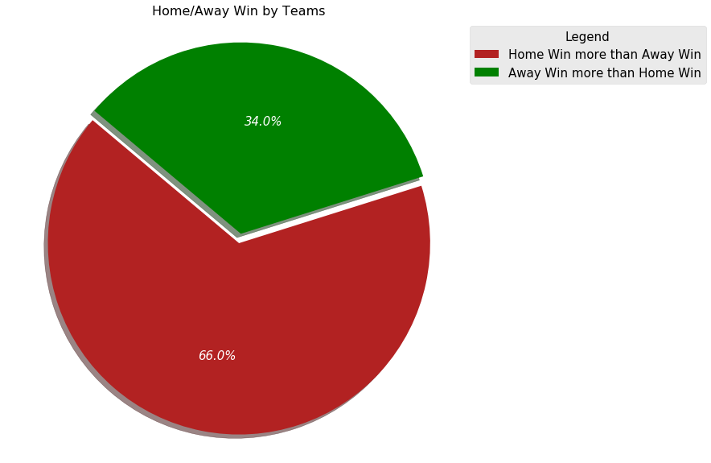

```python
#Create a pie chart where away wins is greater than home wins
explode = (0,0.05)
colors = ['firebrick', 'green']
labels = ['Home Win more than Away Win', 'Away Win more than Home Win']
plt.figure(figsize=(10,10))
plt.pie(away_win_team,explode=explode, colors=colors, labels=labels, autopct='%1.1f%%', shadow=True, startangle=140,
       textprops={'color':'white', 'fontsize':'15', 'style':'italic'})
plt.legend(
          title="Legend",
          loc="upper left",
          bbox_to_anchor=(1, 0, 0.5, 1), fontsize=15, title_fontsize=15)
plt.title('Home/Away Win by Teams', fontdict={'fontsize':'16'})
plt.axis('equal');
```

### Question 2: What are the properties of the players? Is their any relation between player Height/Weight with Rating/Potential ?

```python
#Describe the player datafram
print(df_player.describe())
```

```
              height         weight  overall_rating      potential
count  183978.000000  183978.000000   183978.000000  183978.000000
mean      181.878872     168.776245       68.588601      73.451580
std         6.394818      15.088920        7.037056       6.587741
min       157.480000     117.000000       33.000000      39.000000
25%       177.800000     159.000000       64.000000      69.000000
50%       182.880000     168.000000       69.000000      74.000000
75%       185.420000     179.000000       73.000000      78.000000
max       208.280000     243.000000       94.000000      97.000000
```

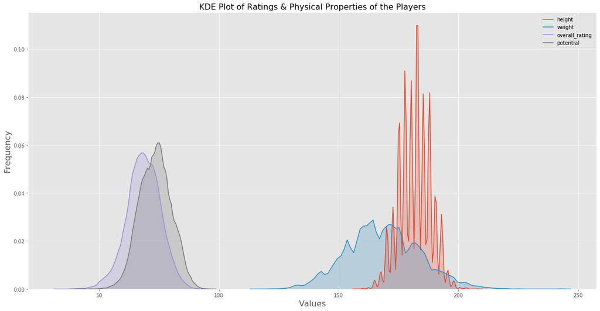

```python
#Make subplots on the same graph of the player dataframe components
plt.figure(figsize=(20,10))
plt.title('KDE Plot of Ratings & Physical Properties of the Players', fontdict={'fontsize':'16'})
plt.xlabel('Values', fontdict={'fontsize':'16'})
plt.ylabel('Frequency', fontdict={'fontsize':'16'})
for col in df_player.columns:
    sns.kdeplot(data=df_player[col], shade=True)
```

> **We can infer that overall_rating & potential columns have almost similar distribution so I will create one feature by creating the average element wise. Height and weight can be combined in one feature by calculating the body mass index (BMI)**

$${BMI} = Weight / Height^{2}$$

```python
#Create a new data frame for players with only 2 features described above
df_bmi_rating = pd.DataFrame()
df_bmi_rating['rating'] = (df_player.overall_rating.add(df_player.potential))/2
df_bmi_rating['bmi'] = round((df_player.weight/0.45359237).div(((df_player.height/100)**2)),2)
```

```python
#Print Summery Statistics for the players Data Frame
print(df_bmi_rating.describe())
```

```
              rating            bmi
count  183978.000000  183978.000000
mean       71.020090     112.358987
std         6.403443       6.491283
min        37.000000      85.490000
25%        66.500000     107.780000
50%        71.000000     112.280000
75%        75.500000     116.590000
max        95.500000     150.020000
```

### Categorize Rating & Plot it vs BMI Using Box-Plot

```python
#Catogorize Ratings to make a box-plot
categorized_ratings = round(df_bmi_rating.rating,0).astype(int)
```

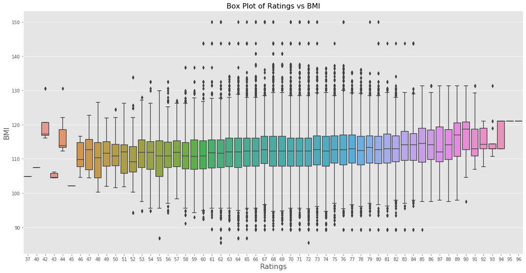

```python
#Make a Box-plot of ratings vs BMI to study the change of statistical Properties
plt.figure(figsize=(20,10))
sns.boxplot(categorized_ratings, df_bmi_rating.bmi)
plt.title('Box Plot of Ratings vs BMI', fontdict={'fontsize':'16'})
plt.xlabel('Ratings', fontdict={'fontsize':'16'})
plt.ylabel('BMI', fontdict={'fontsize':'16'});
```

> **We Can see that there is a slight positive correlation between Ratings and BMI, where the mean of BMI is near 110 for low ratings then it increases gradually to 120 for height ratings.**

## First Question:

> **As for the first Question we can infer that all countries & leagues have a higher home-win than away-win Probability, while not all teams have home-win higher than away-win. As a conclusion we can say that biting against home country or league might be a bad idea based on probabilities, while it might be good idea to bit against home country depending on the playing team.**

## Second Question:

> **Body Mass Index have a slight correlation with the rating of the player, so it provides `no effect` on the player rating, As a conclusion we need to extract other features from the database that can explain the rating of the player.**